# Abalone Age Prediction - Kaggle Playground Series (Season 4, Episode 4) 🐚🔮

## Introduction 🌊

This competition invites you to explore the fascinating world of abalones and test your machine learning prowess. By predicting the age of abalones accurately, you'll unlock insights into these marine mollusks and their growth patterns.

## **Objective** 🎯

Your mission is to develop robust machine learning models capable of accurately predicting the age of abalones based on their physical attributes.

## **Evaluation** 📊

Your submissions will be evaluated using the **Root Mean Squared Logarithmic Error (RMSLE)** metric. This metric ensures your predictions are as close as possible to the true values while penalizing large errors.

[figure not shown]

## Dataset 📦

The dataset for this competition includes various physical measurements of abalones, such as length, diameter, height, and weight. These features serve as valuable indicators of abalone age.

## Files 📄

- **train.csv**: Training dataset containing abalone measurements and their corresponding ages.
- **test.csv**: Test dataset for which you need to predict the abalone ages.
- **sample_submission.csv**: A sample submission file demonstrating the correct format for predictions.

## Installation & Usage 💻

Follow these simple steps to get started:

1. **Clone the Repository**:

   ```
   git clone https://github.com/yashksaini-coder/Abalone-age-prediction
   ```

2. **Navigate to the Repository Directory**:

   ```
   cd Abalone-age-prediction
   ```

3. **Install Dependencies**:

   ```
   pip install -r requirements.txt
   ```

**Explore the dataset, develop your machine learning models, and submit your predictions through the Kaggle competition platform before the deadline.**

## Dependencies 🛠️

- Python 3.9
- Data manipulation libraries (e.g., Pandas, NumPy)
- Machine learning libraries (e.g., Scikit-learn, TensorFlow, PyTorch)

### 🐚✨ **Author**:-

### [Linkedin](https://www.linkedin.com/in/yashksaini/)

### [GitHub](https://github.com/yashksaini-coder)

```python
# Importing the basic libraries
import numpy as np
import pandas as pd
import matplotlib.pyplot as plt
import seaborn as sns


from xgboost import XGBRegressor
from sklearn.model_selection import train_test_split
from sklearn.preprocessing import OrdinalEncoder
from sklearn.metrics import mean_squared_log_error

import skimpy
import warnings
# Disable all warnings
warnings.filterwarnings ('ignore')
```

```python
train = pd.read_csv('playground-series-s4e4/train.csv')
```

```python
train.head()
```

|  | id | Sex | Length | Diameter | Height | Whole weight | Whole weight.1 | Whole weight.2 | Shell weight | Rings |
| --- | --- | --- | --- | --- | --- | --- | --- | --- | --- | --- |
| 0 | 0 | F | 0.550 | 0.430 | 0.150 | 0.7715 | 0.3285 | 0.1465 | 0.2400 | 11 |
| 1 | 1 | F | 0.630 | 0.490 | 0.145 | 1.1300 | 0.4580 | 0.2765 | 0.3200 | 11 |
| 2 | 2 | I | 0.160 | 0.110 | 0.025 | 0.0210 | 0.0055 | 0.0030 | 0.0050 | 6 |
| 3 | 3 | M | 0.595 | 0.475 | 0.150 | 0.9145 | 0.3755 | 0.2055 | 0.2500 | 10 |
| 4 | 4 | I | 0.555 | 0.425 | 0.130 | 0.7820 | 0.3695 | 0.1600 | 0.1975 | 9 |

```python
train.info()
```

```
<class 'pandas.core.frame.DataFrame'>
RangeIndex: 90615 entries, 0 to 90614
Data columns (total 10 columns):
 #   Column          Non-Null Count  Dtype
---  ------          --------------  -----
 0   id              90615 non-null  int64
 1   Sex             90615 non-null  object
 2   Length          90615 non-null  float64
 3   Diameter        90615 non-null  float64
 4   Height          90615 non-null  float64
 5   Whole weight    90615 non-null  float64
 6   Whole weight.1  90615 non-null  float64
 7   Whole weight.2  90615 non-null  float64
 8   Shell weight    90615 non-null  float64
 9   Rings           90615 non-null  int64
dtypes: float64(7), int64(2), object(1)
memory usage: 6.9+ MB
```

```python
train.isnull().sum()
```

```
id                0
Sex               0
Length            0
Diameter          0
Height            0
Whole weight      0
Whole weight.1    0
Whole weight.2    0
Shell weight      0
Rings             0
dtype: int64
```

## EDA (Explorartory Data Analysis)

```python
from skimpy import skim
skim(train)
```

```
╭──────────────────────────────────────────────── skimpy summary ─────────────────────────────────────────────────╮
│          Data Summary                Data Types                                                                 │
│ ┏━━━━━━━━━━━━━━━━━━━┳━━━━━━━━┓ ┏━━━━━━━━━━━━━┳━━━━━━━┓                                                          │
│ ┃ dataframe         ┃ Values ┃ ┃ Column Type ┃ Count ┃                                                          │
│ ┡━━━━━━━━━━━━━━━━━━━╇━━━━━━━━┩ ┡━━━━━━━━━━━━━╇━━━━━━━┩                                                          │
│ │ Number of rows    │ 90615  │ │ float64     │ 7     │                                                          │
│ │ Number of columns │ 10     │ │ int32       │ 2     │                                                          │
│ └───────────────────┴────────┘ │ string      │ 1     │                                                          │
│                                └─────────────┴───────┘                                                          │
│                                                     number                                                      │
│ ┏━━━━━━━━━━━━━━━━━━━┳━━━━━┳━━━━━━━┳━━━━━━━━━┳━━━━━━━━┳━━━━━━━━━━┳━━━━━━━━┳━━━━━━━━┳━━━━━━━━┳━━━━━━━━┳━━━━━━━━┓  │
│ ┃ column_name       ┃ NA  ┃ NA %  ┃ mean    ┃ sd     ┃ p0       ┃ p25    ┃ p50    ┃ p75    ┃ p100   ┃ hist   ┃  │
│ ┡━━━━━━━━━━━━━━━━━━━╇━━━━━╇━━━━━━━╇━━━━━━━━━╇━━━━━━━━╇━━━━━━━━━━╇━━━━━━━━╇━━━━━━━━╇━━━━━━━━╇━━━━━━━━╇━━━━━━━━┩  │
│ │ id                │   0 │     0 │   45000 │  26000 │        0 │  23000 │  45000 │  68000 │  91000 │ ▇▇▇▇▇▇ │  │
│ │ Length            │   0 │     0 │    0.52 │   0.12 │    0.075 │   0.45 │   0.55 │    0.6 │   0.81 │  ▁▃▇▇▁ │  │
│ │ Diameter          │   0 │     0 │     0.4 │  0.098 │    0.055 │   0.34 │   0.42 │   0.47 │   0.65 │  ▂▃▇▇▁ │  │
│ │ Height            │   0 │     0 │    0.14 │  0.038 │        0 │   0.11 │   0.14 │   0.16 │    1.1 │   ▇▁   │  │
│ │ Whole weight      │   0 │     0 │    0.79 │   0.46 │    0.002 │   0.42 │    0.8 │    1.1 │    2.8 │  ▇▇▆▂  │  │
│ │ Whole weight.1    │   0 │     0 │    0.34 │    0.2 │    0.001 │   0.18 │   0.33 │   0.46 │    1.5 │  ▆▇▃▁  │  │
│ │ Whole weight.2    │   0 │     0 │    0.17 │    0.1 │   0.0005 │  0.086 │   0.17 │   0.23 │   0.76 │  ▇▇▃   │  │
│ │ Shell weight      │   0 │     0 │    0.23 │   0.13 │   0.0015 │   0.12 │   0.23 │    0.3 │      1 │  ▆▇▃   │  │
│ │ Rings             │   0 │     0 │     9.7 │    3.2 │        1 │      8 │      9 │     11 │     29 │  ▁▇▃▁  │  │
│ └───────────────────┴─────┴───────┴─────────┴────────┴──────────┴────────┴────────┴────────┴────────┴────────┘  │
│                                                     string                                                      │
│ ┏━━━━━━━━━━━━━━━━━━━━━━━━━━━┳━━━━━━━━━┳━━━━━━━━━━━━┳━━━━━━━━━━━━━━━━━━━━━━━━━━━━━━┳━━━━━━━━━━━━━━━━━━━━━━━━━━┓  │
│ ┃ column_name               ┃ NA      ┃ NA %       ┃ words per row                ┃ total words              ┃  │
│ ┡━━━━━━━━━━━━━━━━━━━━━━━━━━━╇━━━━━━━━━╇━━━━━━━━━━━━╇━━━━━━━━━━━━━━━━━━━━━━━━━━━━━━╇━━━━━━━━━━━━━━━━━━━━━━━━━━┩  │
│ │ Sex                       │       0 │          0 │                            1 │                    90615 │  │
│ └───────────────────────────┴─────────┴────────────┴──────────────────────────────┴──────────────────────────┘  │
╰────────────────────────────────────────────────────── End ──────────────────────────────────────────────────────╯
```

```python
df = train.copy(deep='True')
df = df.drop(columns='id',axis=1)
```

```python
df.head()
```

|  | Sex | Length | Diameter | Height | Whole weight | Whole weight.1 | Whole weight.2 | Shell weight | Rings |
| --- | --- | --- | --- | --- | --- | --- | --- | --- | --- |
| 0 | F | 0.550 | 0.430 | 0.150 | 0.7715 | 0.3285 | 0.1465 | 0.2400 | 11 |
| 1 | F | 0.630 | 0.490 | 0.145 | 1.1300 | 0.4580 | 0.2765 | 0.3200 | 11 |
| 2 | I | 0.160 | 0.110 | 0.025 | 0.0210 | 0.0055 | 0.0030 | 0.0050 | 6 |
| 3 | M | 0.595 | 0.475 | 0.150 | 0.9145 | 0.3755 | 0.2055 | 0.2500 | 10 |
| 4 | I | 0.555 | 0.425 | 0.130 | 0.7820 | 0.3695 | 0.1600 | 0.1975 | 9 |

```python
numeric_features = df.select_dtypes(include = ['int', 'float']).columns.to_list()
categoric_features = df.select_dtypes(include = ['object', 'category']).columns.to_list()
```

```python
numeric_features
```

```
['Length',
 'Diameter',
 'Height',
 'Whole weight',
 'Whole weight.1',
 'Whole weight.2',
 'Shell weight',
 'Rings']
```

```python
categoric_features
```

```
['Sex']
```

## Hist Plot

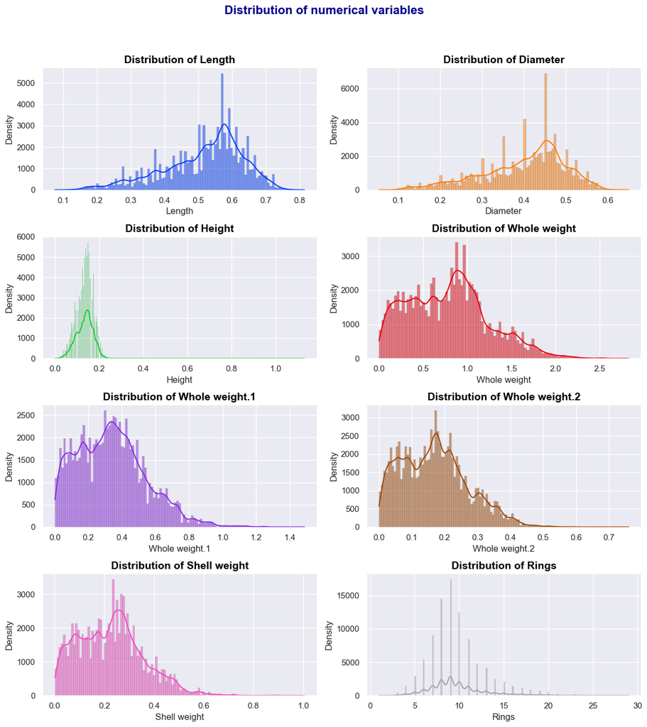

```python
sns.set_style(style="darkgrid")
colors = sns.color_palette(palette='bright', n_colors=len(numeric_features))
fig, axs = plt.subplots(nrows=4, ncols=2, figsize=(12, 14))
axs = axs.flat

# Loop through each numeric feature and plot its distribution
for i, num_feat in enumerate(numeric_features):
    sns.histplot(df[num_feat], kde=True, color=colors[i], ax=axs[i], edgecolor="gray")
    axs[i].set_xlabel(num_feat, fontsize=12)
    axs[i].set_ylabel("Density", fontsize=12)
    axs[i].set_title(f"Distribution of {num_feat}", fontsize=14, fontweight='bold', color="black")


for j in range(len(numeric_features), len(axs)):
    fig.delaxes(axs[j])

fig.suptitle("Distribution of numerical variables", fontsize=16, fontweight="bold", color="darkblue")
fig.tight_layout(rect=[0, 0.03, 1, 0.95])  # Adjust the layout to accommodate the suptitle
plt.show()
```

## Pair Plot

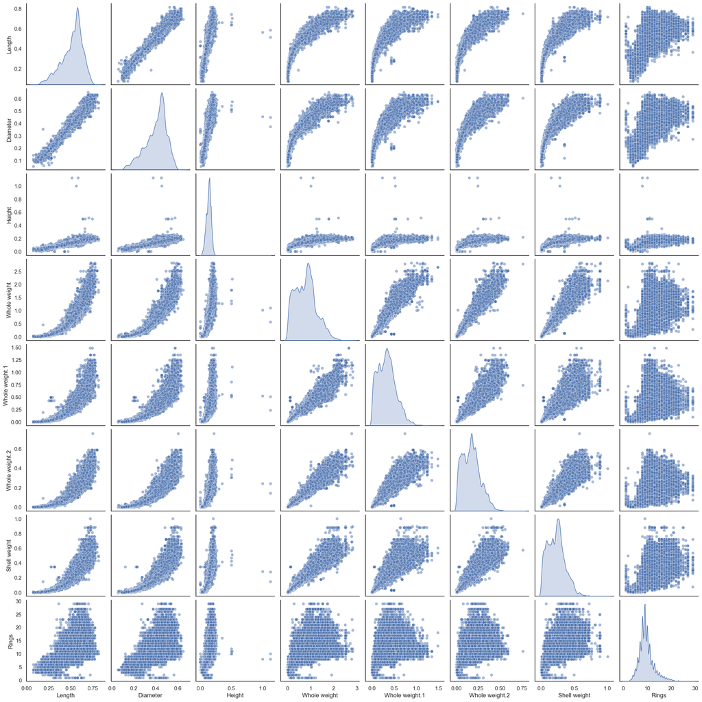

```python
sns.set(style="white")
sns.pairplot(df, diag_kind="kde", markers="o", plot_kws={"alpha": 0.5})
plt.show()
```

## Box Plot

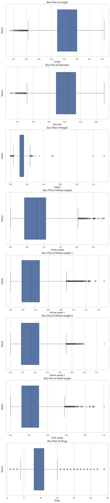

```python
sns.set(style="whitegrid")
fig, axs = plt.subplots(nrows=len(numeric_features), figsize=(10, 6 * len(numeric_features)))

# Loop through each numerical feature and create a box plot
for i, num_feat in enumerate(numeric_features):
    sns.boxplot(x=num_feat, data=df, ax=axs[i])
    axs[i].set_title(f"Box Plot of {num_feat}", fontsize=14)
    axs[i].set_xlabel(num_feat, fontsize=12)
    axs[i].set_ylabel("Values", fontsize=12)

# plt.tight_layout()
plt.show()
```

## Q-Q Plot

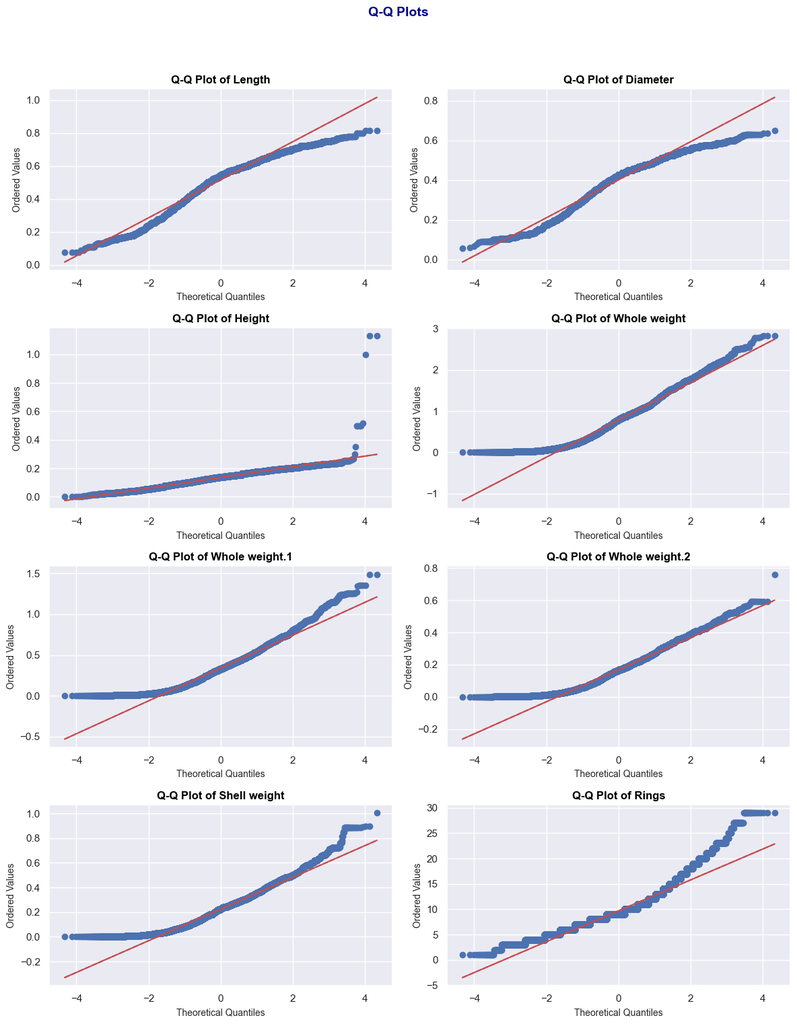

```python
import scipy.stats as stats
sns.set_style(style="darkgrid")
fig, axs = plt.subplots(nrows=4, ncols=2, figsize=(12, 16))
axs = axs.flat

# Loop through each numerical feature and create a Q-Q plot
for i, num_feat in enumerate(numeric_features):
    # Generate Q-Q plot
    stats.probplot(df[num_feat], dist="norm", plot=axs[i])

    # Add reference line
    axs[i].plot(axs[i].get_lines()[1].get_xdata(), axs[i].get_lines()[1].get_ydata(), color='r', linestyle='--')
    axs[i].set_title(f"Q-Q Plot of {num_feat}", fontsize=12, fontweight='bold', color="black")
    axs[i].set_xlabel("Theoretical Quantiles", fontsize=10)
    axs[i].set_ylabel("Ordered Values", fontsize=10)

fig.suptitle("Q-Q Plots", fontsize=14, fontweight="bold", color="darkblue")
fig.tight_layout(rect=[0, 0.03, 1, 0.95])
plt.show()
```

## Pie Plot

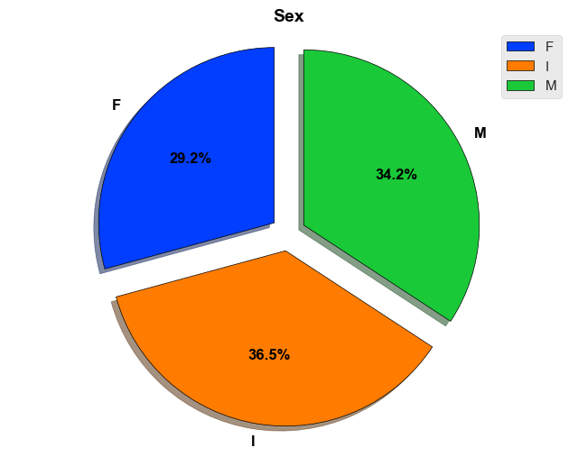

```python
from collections import Counter
plt.style.use("ggplot")
category_data = df[categoric_features[0]]
category_counts = Counter(category_data)

plt.figure(figsize=(8, 6))
plt.pie(x=list(category_counts.values()),
        labels=list(category_counts.keys()),
        colors=[color for color in sns.color_palette(palette='bright', n_colors=3)],
        shadow=True,
        wedgeprops={'edgecolor': 'black'},
        textprops={'fontsize': 12, 'fontweight': 'bold', 'color': 'black'},
        autopct="%.1f%%",
        startangle=90,
        explode=[0.1] * len(category_counts))

plt.title(categoric_features[0], fontsize=14, fontweight='bold', color='black')
plt.legend(loc="upper right")
plt.axis("equal")
plt.show()
```

## Correlation Matrix

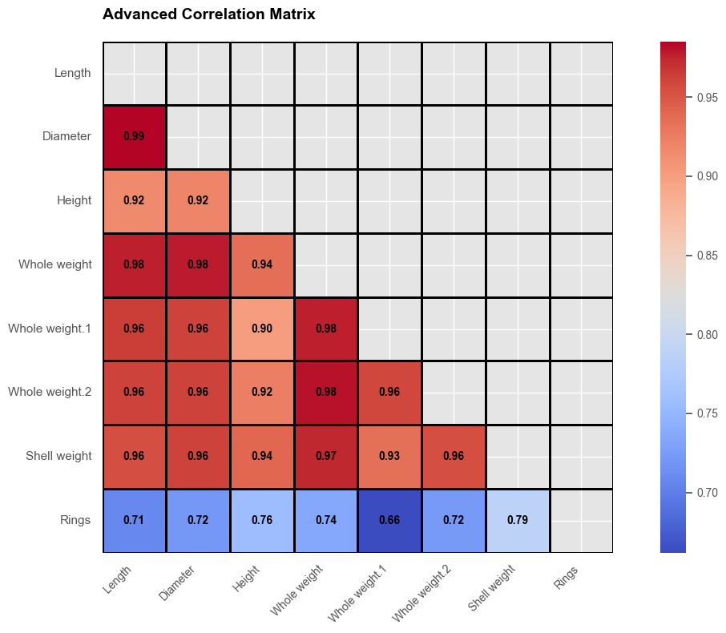

```python
corr_matrix = df[numeric_features].corr(method="spearman")
mask = np.triu(np.ones_like(corr_matrix, dtype=bool))
fig, ax = plt.subplots(figsize=(12, 8))

sns.heatmap(corr_matrix,
            cmap="coolwarm",
            annot=True,
            fmt=".2f",
            annot_kws={'fontsize': 10, 'fontweight': 'bold', 'color': 'black'},
            linewidths=1,
            linecolor='black',
            square=True,
            mask=mask,
            ax=ax)

ax.set_xticklabels(ax.get_xticklabels(), rotation=45, horizontalalignment='right', fontsize=10)
ax.set_title("Advanced Correlation Matrix", fontsize=14, fontweight="bold", color="black", loc='left', pad=20)
cbar = ax.collections[0].colorbar
cbar.ax.tick_params(labelsize=10)
for i in range(len(corr_matrix)):
    ax.axhline(i, color='black', lw=1)
    ax.axvline(i, color='black', lw=1)

fig.tight_layout()
plt.show()
```

## Feature Processing

```python
test = pd.read_csv('playground-series-s4e4/test.csv')
test.head()
```

|  | id | Sex | Length | Diameter | Height | Whole weight | Whole weight.1 | Whole weight.2 | Shell weight |
| --- | --- | --- | --- | --- | --- | --- | --- | --- | --- |
| 0 | 90615 | M | 0.645 | 0.475 | 0.155 | 1.2380 | 0.6185 | 0.3125 | 0.3005 |
| 1 | 90616 | M | 0.580 | 0.460 | 0.160 | 0.9830 | 0.4785 | 0.2195 | 0.2750 |
| 2 | 90617 | M | 0.560 | 0.420 | 0.140 | 0.8395 | 0.3525 | 0.1845 | 0.2405 |
| 3 | 90618 | M | 0.570 | 0.490 | 0.145 | 0.8740 | 0.3525 | 0.1865 | 0.2350 |
| 4 | 90619 | I | 0.415 | 0.325 | 0.110 | 0.3580 | 0.1575 | 0.0670 | 0.1050 |

```python
ordinal = OrdinalEncoder(dtype='float')
```

```python
train[categoric_features] = ordinal.fit_transform(train[categoric_features])
test[categoric_features] = ordinal.transform(test[categoric_features])
```

## Model Training

```python
test = test.drop(columns=['id'], axis=1)
train = train.drop(columns=['id'], axis=1)


y = train.Rings
X = train.drop(['Rings'], axis=1)
```

```python
from sklearn.feature_selection import mutual_info_regression

discrete_features = X.dtypes == int

def mi_score_maker(X,y,discrete_features):
    scores = mutual_info_regression(X,y,discrete_features=discrete_features)
    df = pd.DataFrame({
        'Features':X.columns,
        'Scores':scores
    })
    df = df.sort_values(['Scores'],ascending=False).reset_index(drop=True)
    return df
```

```python
mi_scores = mi_score_maker(X,y.astype('float64'),discrete_features)
```

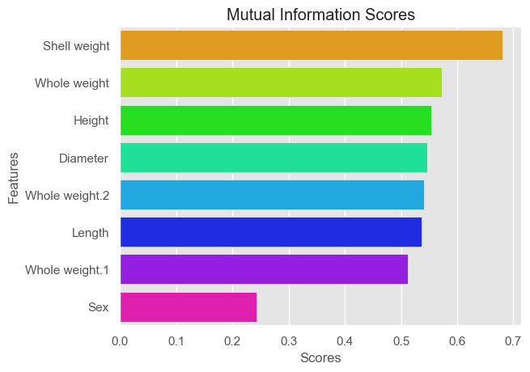

```python
colors = sns.color_palette('hsv', len(mi_scores))
sns.barplot(x='Scores',y='Features',data=mi_scores, palette=colors)
plt.title("Mutual Information Scores")
plt.show()
```

```python
X_train, X_val, y_train, y_val = train_test_split(X, y, test_size=0.2, random_state=21)
```

```python
xgb_params = {
    'verbosity': 0,
    "early_stopping_rounds":25,
    'n_estimators': 1500,
    'eval_metric': 'rmse',
    'random_state':1234,
    'max_depth': 8,
    'subsample': 0.79,
    'objective': 'reg:squarederror',
    'learning_rate': 0.013,
    'colsample_bytree': 0.56,
    "min_child_weight": 10,
}

xgb_model = XGBRegressor(**xgb_params)
```

```python
xgb_model.fit(X_train, y_train, eval_set=[(X_val, y_val)], verbose=False)
```

```
XGBRegressor(base_score=None, booster=None, callbacks=None,
             colsample_bylevel=None, colsample_bynode=None,
             colsample_bytree=0.56, device=None, early_stopping_rounds=25,
             enable_categorical=False, eval_metric='rmse', feature_types=None,
             gamma=None, grow_policy=None, importance_type=None,
             interaction_constraints=None, learning_rate=0.013, max_bin=None,
             max_cat_threshold=None, max_cat_to_onehot=None,
             max_delta_step=None, max_depth=8, max_leaves=None,
             min_child_weight=10, missing=nan, monotone_constraints=None,
             multi_strategy=None, n_estimators=1500, n_jobs=None,
             num_parallel_tree=None, random_state=1234, ...)
```

## Predictions

```python
pred = xgb_model.predict(X_val)
```

```python
pred
```

```
array([ 8.729883,  9.5491  ,  7.203663, ...,  9.503734,  9.675576,
       11.117143], dtype=float32)
```

```python
print("The RMSLE score is: ", mean_squared_log_error(pred, y_val)**0.5)
```

```
The RMSLE score is:  0.14970180113973386
```

```python
predictions = xgb_model.predict(test)
```

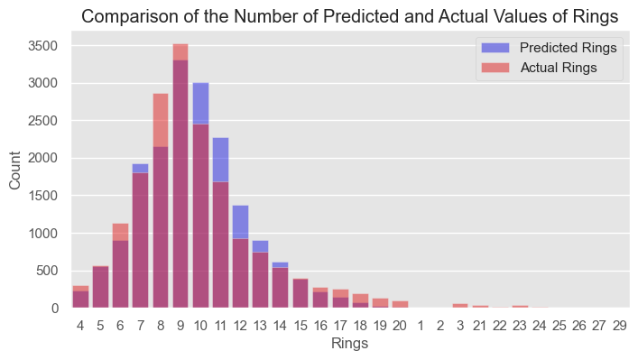

```
CPU times: total: 281 ms
Wall time: 655 ms
```

```python
%%time

df_pred = pd.DataFrame({'Rings': pred.round().astype(int)})
df_vald = pd.DataFrame({'Rings': y_val})
plt.figure(figsize=(8, 4))
sns.countplot(x='Rings', data=df_pred, color='blue', alpha=0.5, label='Predicted Rings')
sns.countplot(x='Rings', data=df_vald, color='red', alpha=0.5, label='Actual Rings')
plt.title("Comparison of the Number of Predicted and Actual Values of Rings")
plt.xlabel('Rings')
plt.ylabel('Count')
plt.legend()
plt.show()
```

## Submission

**V1**

```python
# submission = pd.read_csv('playground-series-s4e4/sample_submission.csv')

# submission['Rings'] = predictions
# submission.to_csv('submission.csv', index=False)
```

**V2**

```python
submission = pd.read_csv('playground-series-s4e4/sample_submission.csv')

submission['Rings'] = predictions
submission.to_csv('submission2.csv', index=False)
```